# u3229387 RDA project

Aravind Madineni

09/05/2021

## Load required packages

```r
library(tidyverse) # include all required packages at the start
library(broom)
```

## (a) Basket ball, one of the most popular sports in the world played between two teams of just five players on each rectangular court, is just played with a ball and a hoop where you score a point by shooting the ball through the hoop. The game is very fat st paced where each and every player needs to play their part in defense and offence. In basketball the key metrics or key performance indicators arescoring the ball which is called as a goal or basket, control the ball, rebounds and free throws.There are five differnt positions to be considered for this sport, the positions being center, powerforward(PF), point gaurd(PG), shooting gaurd(SG),samll forward(SF). Height is the major requirement of the centre position where one tries to block the oppponents and also rebounds both offensive and defensive. Power forward also does all that are done by the centre except that PF takes longer shots than centre. Small Forward cover all the court scoring from long shots but also close ones. Point Gaurds are supposed to be the teams best dribbler and also passer and also should steal the ball. shooting gaurd(SG), as the name suggests is the best shooter in the team ,able to make long shots, good dribbler as well.

##(b) The scenario is that being a data analyst of one of the baskeball teams called as chicago bulls which is competing in the NBA need to analyse the performance. In the recent NBA season the performance of the team was not up to the mark as it finshes fourth from the bottom where a budget of $118 million was given for the next season to produce better results. There are five data sets given which contain information about the players statistics, their salaries, different teams and their statistics and payroll where there is a need to develop a reproducible data analysis project on the basis of this data provided.

##(d) The importance of the project is that it shows the way how any data must be used and analysed in a way where one would eventually achieve the end result, here being able to find out the 5 best players and there by justification of the project can be done where we are able to achieve the end result with the resources provided.

## The data is read using the read.csv function for reading the two required files and initiall the structure 0f data is checked using str() function and missing values if any present are removed using na.omit() function where the whole rows of na’s are removed.

```r
# read in the data
# data dir should be in the working dir
nba_play_st <-  as.data.frame(read.csv("2018-19_nba_player-statistics.csv"))
nba_play_sal <- as.data.frame(read.csv("2018-19_nba_player-salaries.csv"))
```

## Checking the data

##Check the structure of the data file using `str()`:

```r
str(nba_play_st)
```

```
## 'data.frame':    708 obs. of  29 variables:
##  $ player_name: chr  "Alex Abrines" "Quincy Acy" "Jaylen Adams" "Steven Adams" ...
##  $ Pos        : chr  "SG" "PF" "PG" "C" ...
##  $ Age        : int  25 28 22 25 21 21 25 33 21 23 ...
##  $ Tm         : chr  "OKC" "PHO" "ATL" "OKC" ...
##  $ G          : int  31 10 34 80 82 19 7 81 10 38 ...
##  $ GS         : int  2 0 1 80 28 3 0 81 1 2 ...
##  $ MP         : int  588 123 428 2669 1913 194 22 2687 120 416 ...
##  $ FG         : int  56 4 38 481 280 11 3 684 13 67 ...
##  $ FGA        : int  157 18 110 809 486 36 10 1319 39 178 ...
##  $ FG.        : num  0.357 0.222 0.345 0.595 0.576 0.306 0.3 0.519 0.333 0.376 ...
##  $ X3P        : int  41 2 25 0 3 6 0 10 3 32 ...
##  $ X3PA       : int  127 15 74 2 15 23 4 42 12 99 ...
##  $ X3P.       : num  0.323 0.133 0.338 0 0.2 0.261 0 0.238 0.25 0.323 ...
##  $ X2P        : int  15 2 13 481 277 5 3 674 10 35 ...
##  $ X2PA       : int  30 3 36 807 471 13 6 1277 27 79 ...
##  $ X2P.       : num  0.5 0.667 0.361 0.596 0.588 0.385 0.5 0.528 0.37 0.443 ...
##  $ eFG.       : num  0.487 0.278 0.459 0.595 0.579 0.389 0.3 0.522 0.372 0.466 ...
##  $ FT         : int  12 7 7 146 166 4 1 349 8 45 ...
##  $ FTA        : int  13 10 9 292 226 4 2 412 12 60 ...
##  $ FT.        : num  0.923 0.7 0.778 0.5 0.735 1 0.5 0.847 0.667 0.75 ...
##  $ ORB        : int  5 3 11 391 165 3 1 251 11 3 ...
##  $ DRB        : int  43 22 49 369 432 16 3 493 15 20 ...
##  $ TRB        : int  48 25 60 760 597 19 4 744 26 23 ...
##  $ AST        : int  20 8 65 124 184 5 6 194 13 25 ...
##  $ STL        : int  17 1 14 117 71 1 2 43 1 6 ...
##  $ BLK        : int  6 4 5 76 65 4 0 107 0 6 ...
##  $ TOV        : int  14 4 28 135 121 6 2 144 8 33 ...
##  $ PF         : int  53 24 45 204 203 13 4 179 7 47 ...
##  $ PTS        : int  165 17 108 1108 729 32 7 1727 37 211 ...
```

```r
str(nba_play_sal)
```

```
## 'data.frame':    576 obs. of  3 variables:
##  $ player_id  : int  1 2 3 4 5 6 7 8 9 10 ...
##  $ player_name: chr  "Alex Abrines" "Quincy Acy" "Steven Adams" "Jaylen Adams" ...
##  $ salary     : int  3667645 213948 24157304 236854 2955840 77250 5285394 77250 2000000 22347015 ...
```

##Check the first 6 rows of the data file using `head()`

```r
knitr::kable(head(nba_play_sal))
```

| player_id | player_name | salary |
| --- | --- | --- |
| 1 | Alex Abrines | 3667645 |
| 2 | Quincy Acy | 213948 |
| 3 | Steven Adams | 24157304 |
| 4 | Jaylen Adams | 236854 |
| 5 | Bam Adebayo | 2955840 |
| 6 | Deng Adel | 77250 |

```r
knitr::kable(head(nba_play_st))
```

| player_name | Pos | Age | Tm | G | GS | MP | FG | FGA | FG. | X3P | X3PA | X3P. | X2P | X2PA | X2P. | eFG. | FT | FTA | FT. | ORB | DRB | TRB | AST | STL | BLK | TOV | PF | PTS |
| --- | --- | --- | --- | --- | --- | --- | --- | --- | --- | --- | --- | --- | --- | --- | --- | --- | --- | --- | --- | --- | --- | --- | --- | --- | --- | --- | --- | --- |
| Alex Abrines | SG | 25 | OKC | 31 | 2 | 588 | 56 | 157 | 0.357 | 41 | 127 | 0.323 | 15 | 30 | 0.500 | 0.487 | 12 | 13 | 0.923 | 5 | 43 | 48 | 20 | 17 | 6 | 14 | 53 | 165 |
| Quincy Acy | PF | 28 | PHO | 10 | 0 | 123 | 4 | 18 | 0.222 | 2 | 15 | 0.133 | 2 | 3 | 0.667 | 0.278 | 7 | 10 | 0.700 | 3 | 22 | 25 | 8 | 1 | 4 | 4 | 24 | 17 |
| Jaylen Adams | PG | 22 | ATL | 34 | 1 | 428 | 38 | 110 | 0.345 | 25 | 74 | 0.338 | 13 | 36 | 0.361 | 0.459 | 7 | 9 | 0.778 | 11 | 49 | 60 | 65 | 14 | 5 | 28 | 45 | 108 |
| Steven Adams | C | 25 | OKC | 80 | 80 | 2669 | 481 | 809 | 0.595 | 0 | 2 | 0.000 | 481 | 807 | 0.596 | 0.595 | 146 | 292 | 0.500 | 391 | 369 | 760 | 124 | 117 | 76 | 135 | 204 | 1108 |
| Bam Adebayo | C | 21 | MIA | 82 | 28 | 1913 | 280 | 486 | 0.576 | 3 | 15 | 0.200 | 277 | 471 | 0.588 | 0.579 | 166 | 226 | 0.735 | 165 | 432 | 597 | 184 | 71 | 65 | 121 | 203 | 729 |
| Deng Adel | SF | 21 | CLE | 19 | 3 | 194 | 11 | 36 | 0.306 | 6 | 23 | 0.261 | 5 | 13 | 0.385 | 0.389 | 4 | 4 | 1.000 | 3 | 16 | 19 | 5 | 1 | 4 | 6 | 13 | 32 |

##removing the missing values. ##the missing values are removed using the na.omit() function where all the rows having NA’s are removed.

```r
nba_play_st <-  na.omit(nba_play_st)
nba_play_sal <- na.omit(nba_play_sal)
```

##(3) Exploratory analysis

##a) checking for errors and missing values

##Check for missing values using is.na() function

```r
sum(is.na(nba_play_st)) # count the missing values
```

```
## [1] 0
```

```r
sum(is.na(nba_play_sal))
```

```
## [1] 0
```

```r
head(which(is.na(nba_play_st), arr.ind = TRUE)) # find where the missing values are (showing only first 6 rows)
```

```
##      row col
```

## b) checking the distribution of variables using histograms

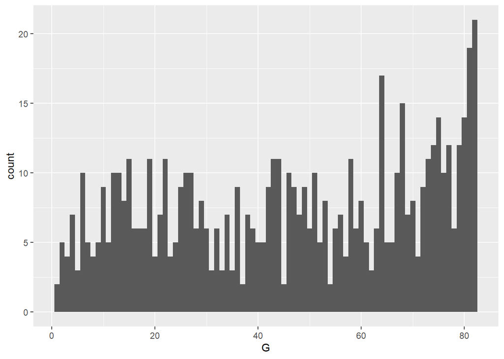

```r
par(mfrow = c(3,3))
ggplot(nba_play_st, aes(x= G))+geom_histogram(binwidth = 1)
```

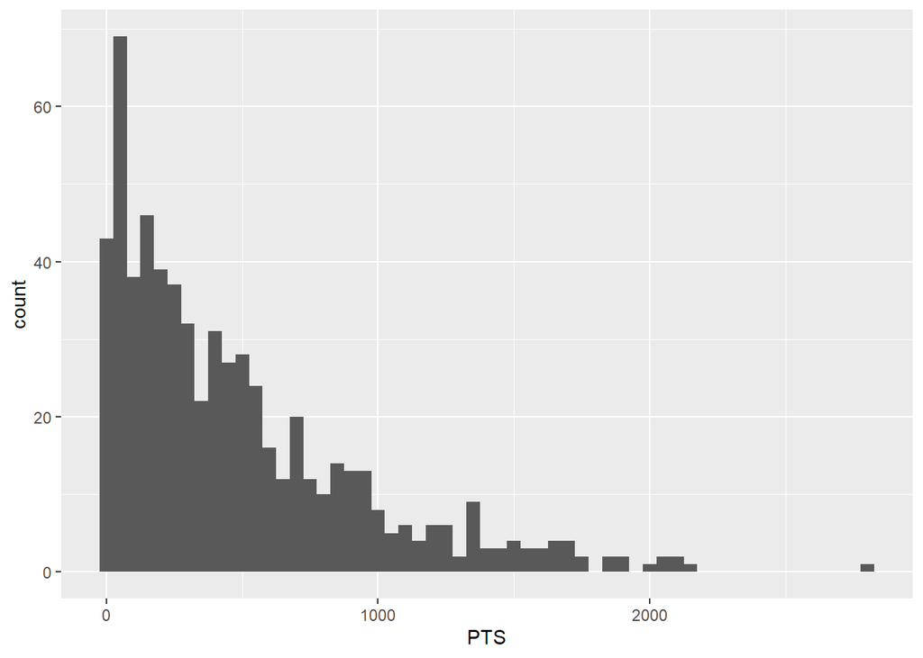

```r
ggplot(nba_play_st, aes(x=PTS)) + geom_histogram(binwidth = 50)
```

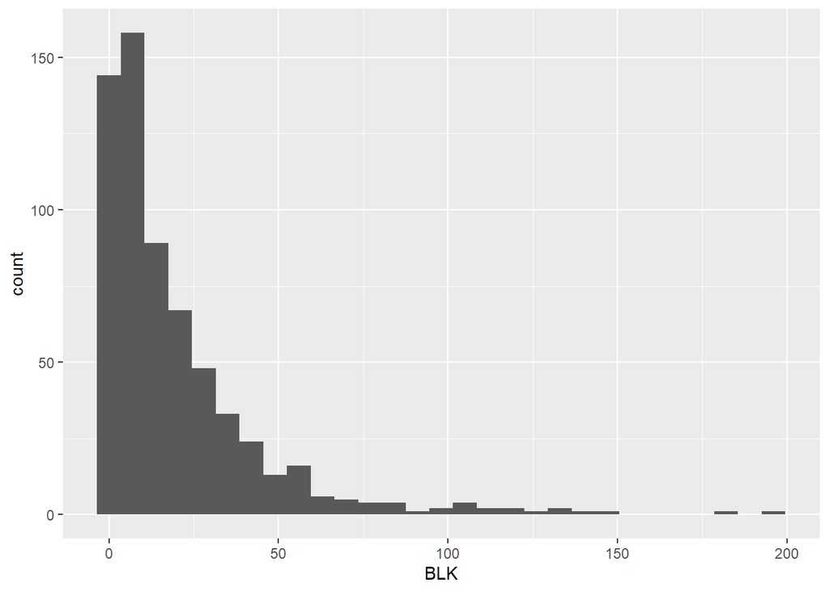

```r
ggplot(nba_play_st, aes(x= BLK))+geom_histogram(binwidth = 7)
```

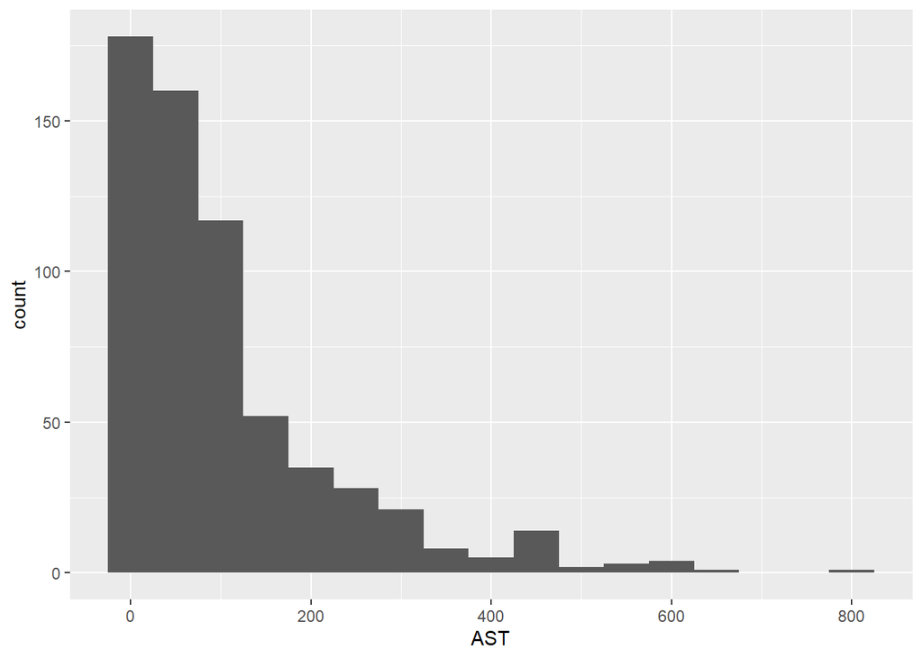

```r
ggplot(nba_play_st, aes(x= AST))+geom_histogram(binwidth = 50)
```

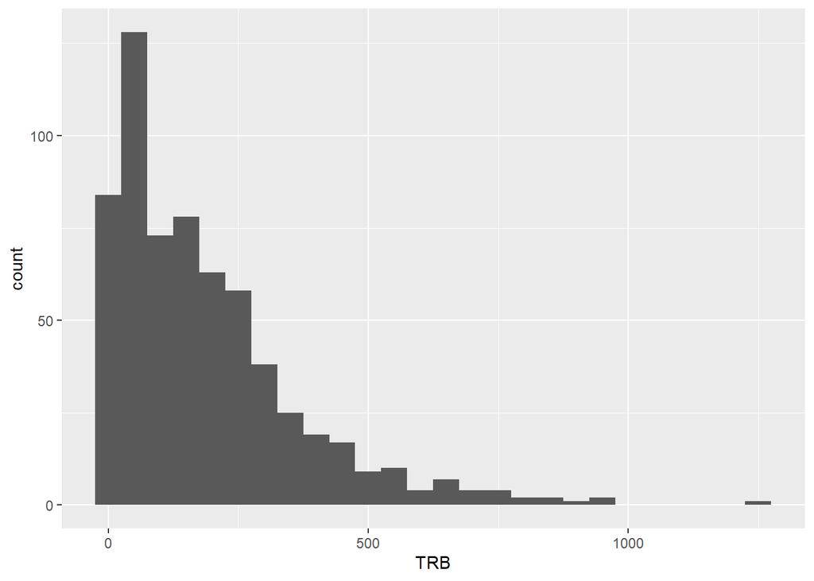

```r
ggplot(nba_play_st, aes(x= TRB))+geom_histogram(binwidth = 50)
```

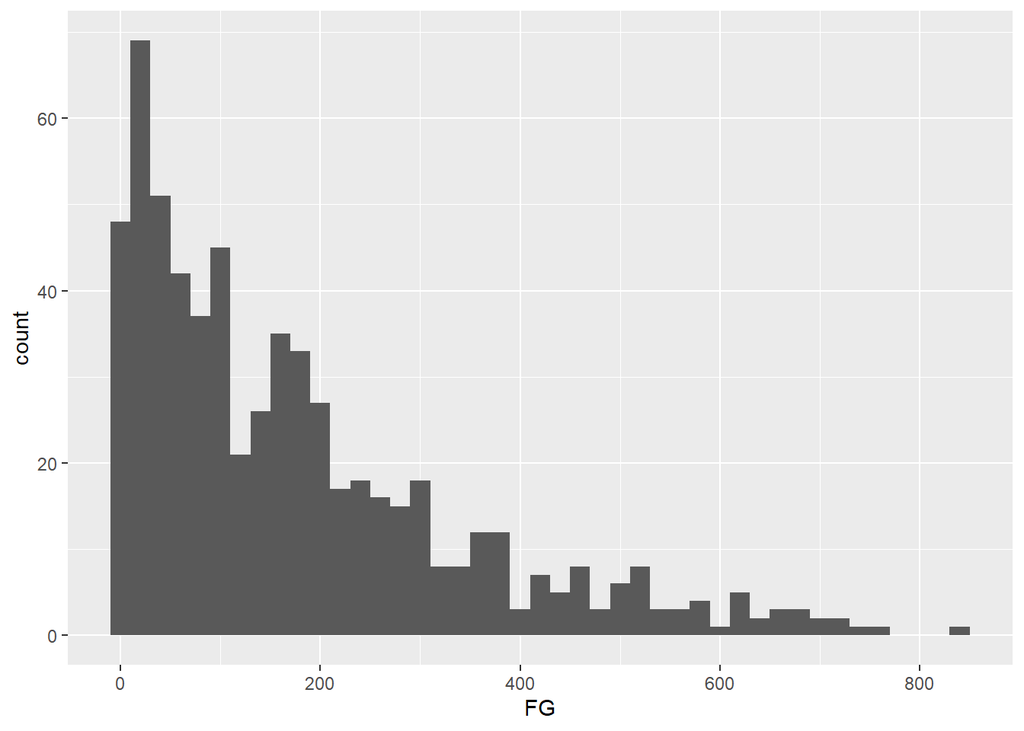

```r
ggplot(nba_play_st, aes(x= FG))+geom_histogram(binwidth = 20)
```

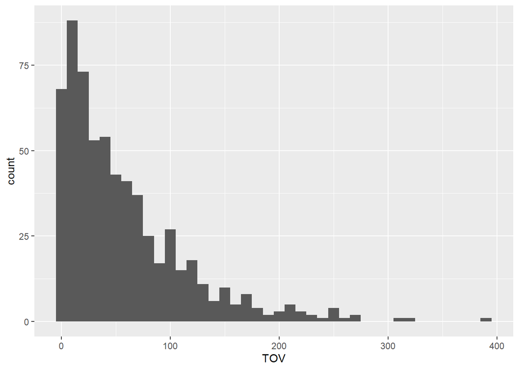

```r
ggplot(nba_play_st, aes(x= TOV))+geom_histogram(binwidth = 10)
```

## By looking at the histograms of all the important variables it can be explicitly understood that most of the distributions are right skewed having a lomg right tail where the mean is present at the right of the peak. This is also called as positive skew distributions.

#####data transformation # Finding the efficency of players using the variables and rounding them to the two digits after decimals and this column is added to the dataset using mutate() function

```r
new_df <- nba_play_st %>%
  filter(G >= mean(G)) %>%
  mutate(play_eff = round((PTS + TRB + AST + STL + BLK - (FGA -FG)-
                             (FTA-FT)- TOV)/ G,digits= 2))
```

##adding salary col using inner join ##inner_join() function is used to join two data sets through the common varaible that exists in two data sets

```r
new_df <- new_df %>% inner_join(nba_play_sal)
```

```r
new_df <- new_df %>%
  mutate(sal_mil = round((salary/1e6),digits = 2))
new_df <- new_df[,-31]
```

##removing duplicate players by sorting the players in descending order of matches played and selecting the top one from the sorted ones

```r
new_df <- new_df[order(new_df$player_name, new_df$G, decreasing=TRUE),]
new_df <- new_df[!duplicated(new_df$player_name),]
```

## saving the file

```r
write.csv(new_df,"new_df_processed.csv")
```

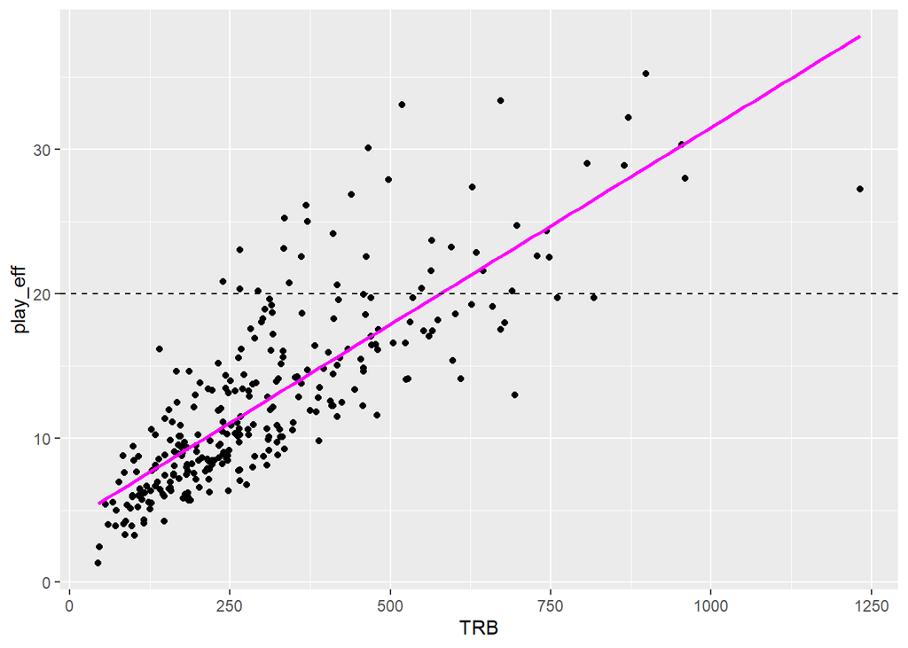

```r
ggplot(data = new_df, aes(x = TRB, y = play_eff)) +
  geom_point() +
 geom_smooth(method = "lm", colour = "magenta", se = FALSE) +
  geom_hline(yintercept = 20, colour = "black", linetype = "dashed")
```

```r
with(new_df, cor(x = TRB, y = play_eff))
```

```
## [1] 0.8060361
```

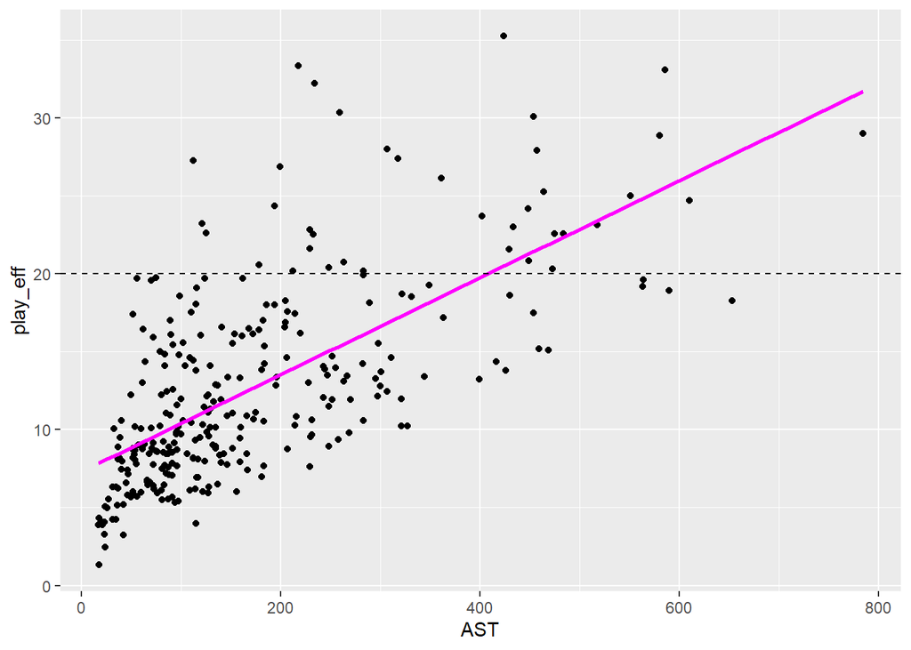

```r
ggplot(data = new_df, aes(x = AST, y = play_eff)) +
  geom_point() +
 geom_smooth(method = "lm", colour = "magenta", se = FALSE) +
  geom_hline(yintercept = 20, colour = "black", linetype = "dashed")
```

```r
with(new_df, cor(x = AST, y = play_eff))
```

```
## [1] 0.6679926
```

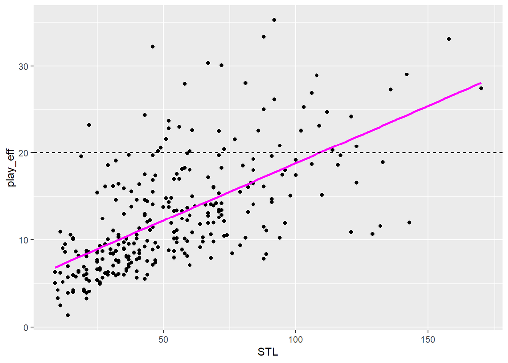

```r
ggplot(data = new_df, aes(x = STL, y = play_eff)) +
  geom_point() +
 geom_smooth(method = "lm", colour = "magenta", se = FALSE) +
  geom_hline(yintercept = 20, colour = "black", linetype = "dashed")
```

```r
with(new_df, cor(x = STL, y = play_eff))
```

```
## [1] 0.6293692
```

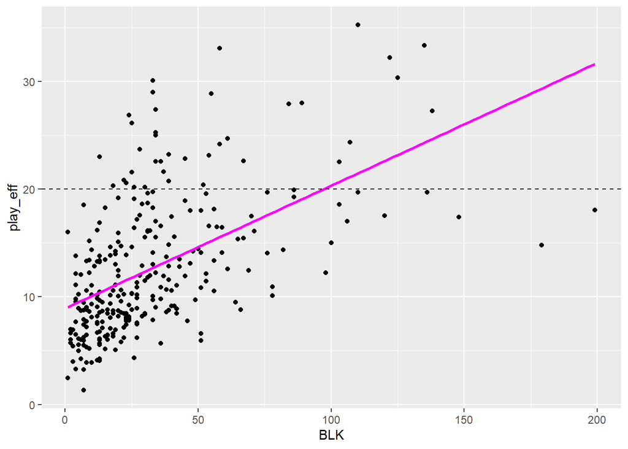

```r
ggplot(data = new_df, aes(x = BLK, y = play_eff)) +
  geom_point() +
 geom_smooth(method = "lm", colour = "magenta", se = FALSE) +
  geom_hline(yintercept = 20, colour = "black", linetype = "dashed")
```

```r
with(new_df, cor(x = BLK, y = play_eff))
```

```
## [1] 0.5437789
```

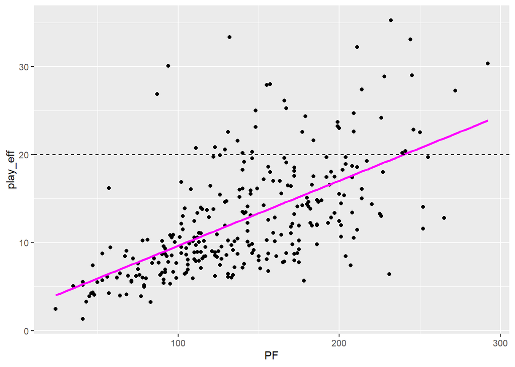

```r
ggplot(data = new_df, aes(x = PF, y = play_eff)) +
  geom_point() +
 geom_smooth(method = "lm", colour = "magenta", se = FALSE) +
  geom_hline(yintercept = 20, colour = "black", linetype = "dashed")
```

```r
with(new_df, cor(x = PF, y = play_eff))
```

```
## [1] 0.6054855
```

##3 the variables Total rebounds(TRB) and player efficiency(play_eff) are in linear relationship and also the they are strongly correlated as seen from the correlation value. The varaibles assists and play_eff are not completely linear as only some points seems to be satisfying the linearity where as other points are scattered and the correlation value is good with 0.66 and same goes with steals and play_eff and the correaltion value is even less with the value of 0.62. The variables blocks and play_eff are not in linear relationship and correaltion is also not so good with value of 0.54. the relation between variables personal fouls and play_eff is a bit linear in some regions and scattered in some regions. the correaltion is better with value 0.6

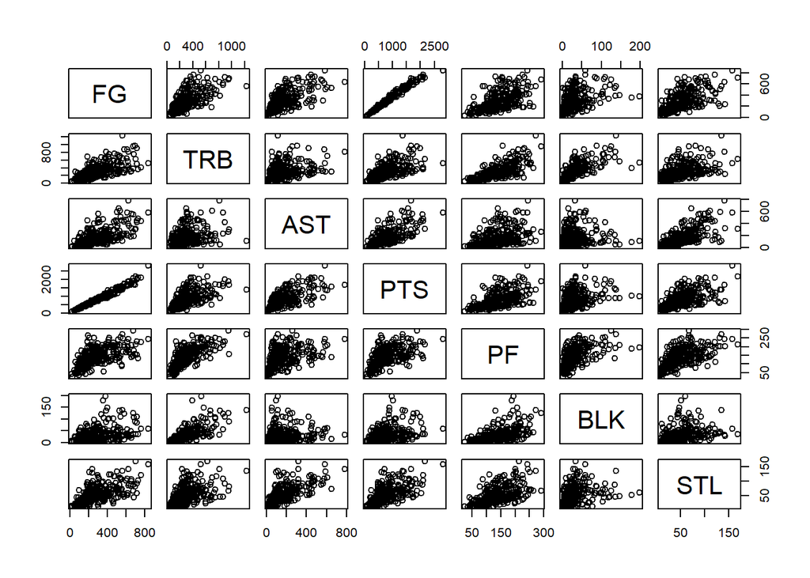

```r
pairs(formula = ~ FG + TRB + AST + PTS + PF + BLK+ STL, data = new_df)
```

##4. Data modelling and results #Multiple linear regression.

```r
fit <- lm(play_eff ~ TRB + AST + PF + BLK+ STL, data = new_df )
tidy(fit, conf.int = TRUE)
```

```
## # A tibble: 6 x 7
##   term        estimate std.error statistic  p.value conf.low conf.high
##   <chr>          <dbl>     <dbl>     <dbl>    <dbl>    <dbl>     <dbl>
## 1 (Intercept)  2.75      0.437        6.29 1.18e- 9  1.89      3.60
## 2 TRB          0.0209    0.00135     15.5  1.11e-39  0.0183    0.0236
## 3 AST          0.0217    0.00153     14.2  6.14e-35  0.0187    0.0248
## 4 PF          -0.0103    0.00434     -2.38 1.78e- 2 -0.0189   -0.00180
## 5 BLK          0.0237    0.00716      3.31 1.04e- 3  0.00963   0.0378
## 6 STL          0.00756   0.00752      1.01 3.16e- 1 -0.00724   0.0224
```

```r
summary(fit)
```

```
##
## Call:
## lm(formula = play_eff ~ TRB + AST + PF + BLK + STL, data = new_df)
##
## Residuals:
##     Min      1Q  Median      3Q     Max
## -6.9745 -1.5366 -0.2503  1.0934 10.1470
##
## Coefficients:
##              Estimate Std. Error t value Pr(>|t|)
## (Intercept)  2.745544   0.436584   6.289 1.18e-09 ***
## TRB          0.020916   0.001354  15.453  < 2e-16 ***
## AST          0.021731   0.001535  14.161  < 2e-16 ***
## PF          -0.010342   0.004340  -2.383  0.01781 *
## BLK          0.023712   0.007155   3.314  0.00104 **
## STL          0.007560   0.007519   1.005  0.31554
## ---
## Signif. codes:  0 '***' 0.001 '**' 0.01 '*' 0.05 '.' 0.1 ' ' 1
##
## Residual standard error: 2.546 on 289 degrees of freedom
## Multiple R-squared:  0.8425, Adjusted R-squared:  0.8398
## F-statistic: 309.3 on 5 and 289 DF,  p-value: < 2.2e-16
```

##. Independence. ##Determine if our linear regression meets the assumption of independence of observations.

```r
car::durbinWatsonTest(fit)
```

```
##  lag Autocorrelation D-W Statistic p-value
##    1      0.02110569      1.950587   0.618
##  Alternative hypothesis: rho != 0
```

# Outliers.

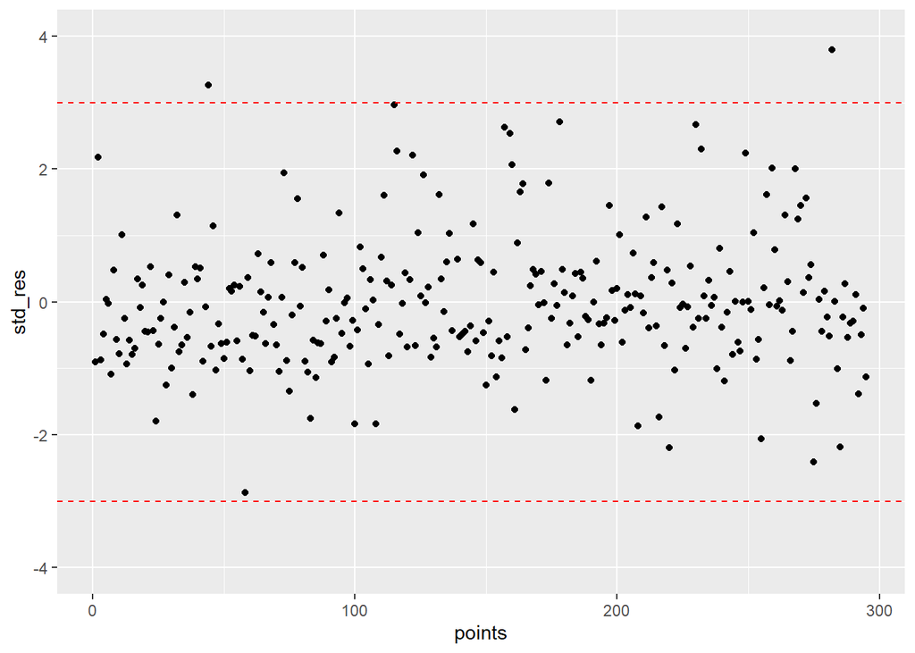

```r
std_res <- rstandard(fit)
points <- 1:length(std_res)

ggplot(data = NULL, aes(x = points, y = std_res)) +
  geom_point() +
  ylim(c(-4,4)) +
  geom_hline(yintercept = c(-3, 3), colour = "red", linetype = "dashed")
```

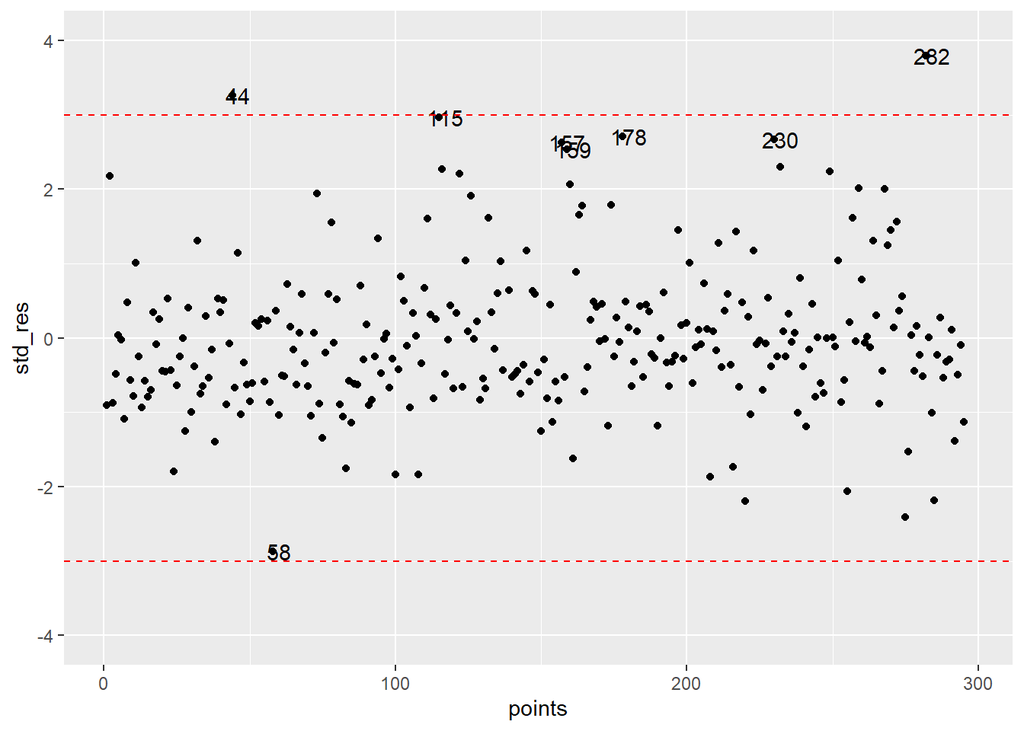

```r
res_labels <- if_else(abs(std_res) >= 2.5, paste(points), "")
ggplot(data = NULL, aes(x = points, y = std_res, label = res_labels)) +
  geom_point() +
  geom_text(nudge_x = 2) +
  ylim(c(-4,4)) +
  geom_hline(yintercept = c(-3, 3), colour = "red", linetype = "dashed")
```

##there are outliers at point 3 and above

##Leverage points. ##Determine if there are any high leverage points that have the potential to influence the model.

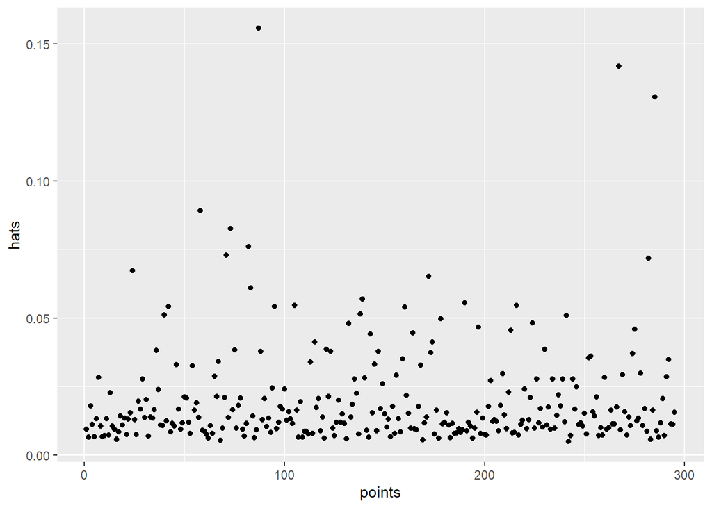

```r
hats <- hatvalues(fit)
ggplot(data = NULL, aes(x = points, y = hats)) +
  geom_point()
```

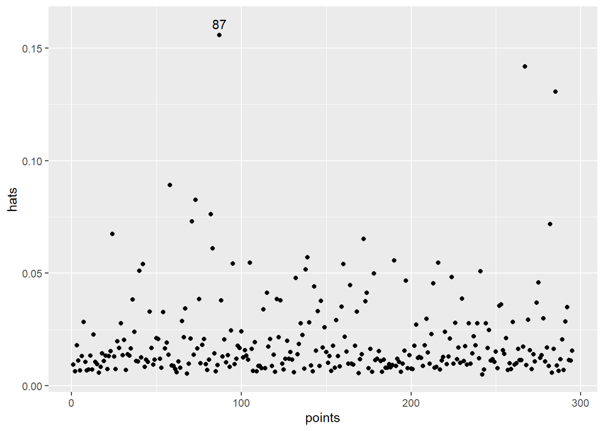

```r
hat_labels <- if_else(hats >= 0.15, paste(points), "")
ggplot(data = NULL, aes(x = points, y = hats)) +
  geom_point() +
  geom_text(aes(label = hat_labels), nudge_y = 0.005)
```

## there are no hatvalues greater than 1, however we might investigate the points above 0.1 as they seem to stick out above the rest

##nfluential points. ##Determine if any of the points could be considered as points of high influence.

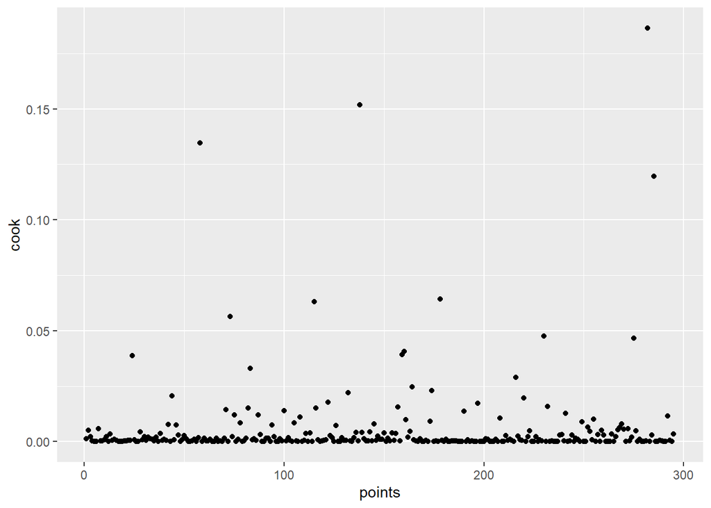

```r
cook <- cooks.distance(fit)
ggplot(data = NULL, aes(x = points, y = cook)) +
  geom_point()
```

## we might take a look at those points above 0.1 that are standing out above the rest

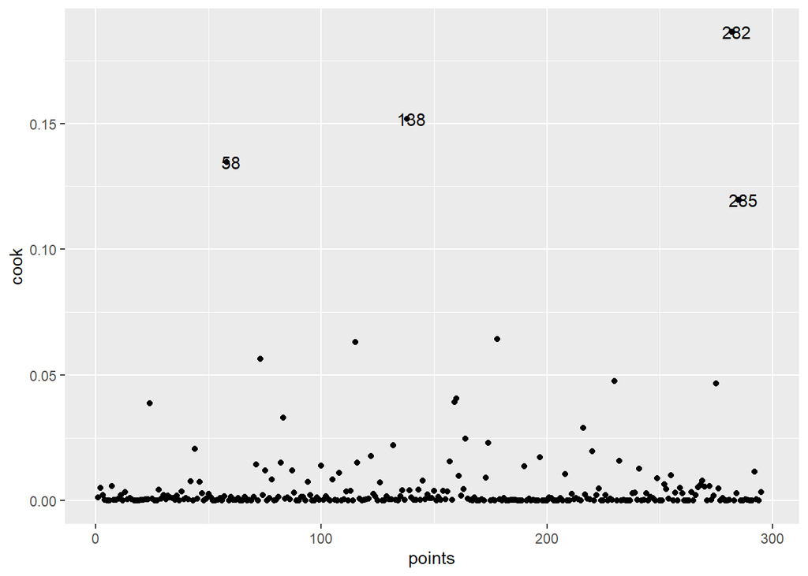

```r
cook_labels <- if_else(cook >= 0.075, paste(points), "")

ggplot(data = NULL, aes(x = points, y = cook)) +
  geom_point() +
  geom_text(aes(label = cook_labels), nudge_x = 2)
```

##Homoscedasticity. ##Check your model for any evidence of heteroscedasticity.

# #we can test for heteroscedasticity by plotting the residuals against

# #the fitted values

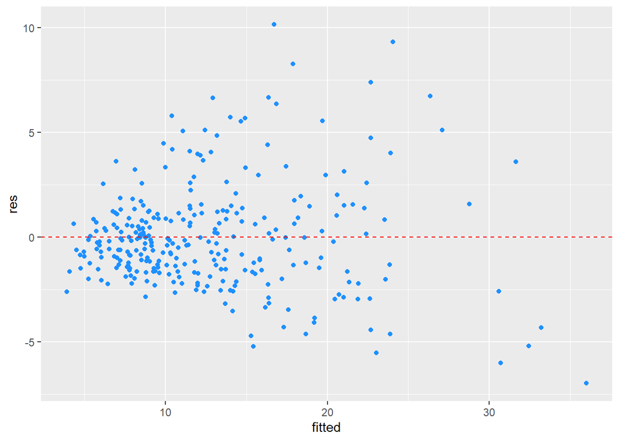

```r
res <- residuals(fit)
fitted <- predict(fit)  # or can use fitted()
ggplot(data = NULL, aes(x = fitted, y = res)) +
  geom_point(colour = "dodgerblue") +
  geom_hline(yintercept = 0, colour = "red", linetype = "dashed")
```

##Normality. ##Are the residuals of your model normally distributed?

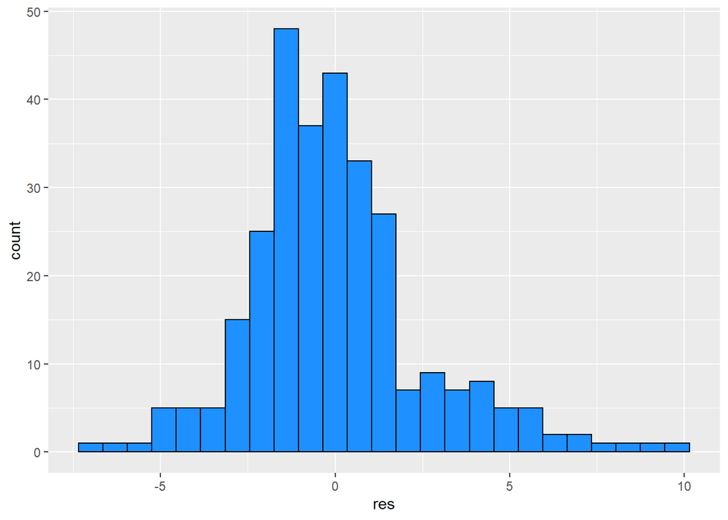

```r
ggplot(data = NULL, aes(x = res)) +
  geom_histogram(colour = "black", fill = "dodgerblue", binwidth = 0.7)
```

## Histogram looks fairly normal and jus a bit skewed to the right.

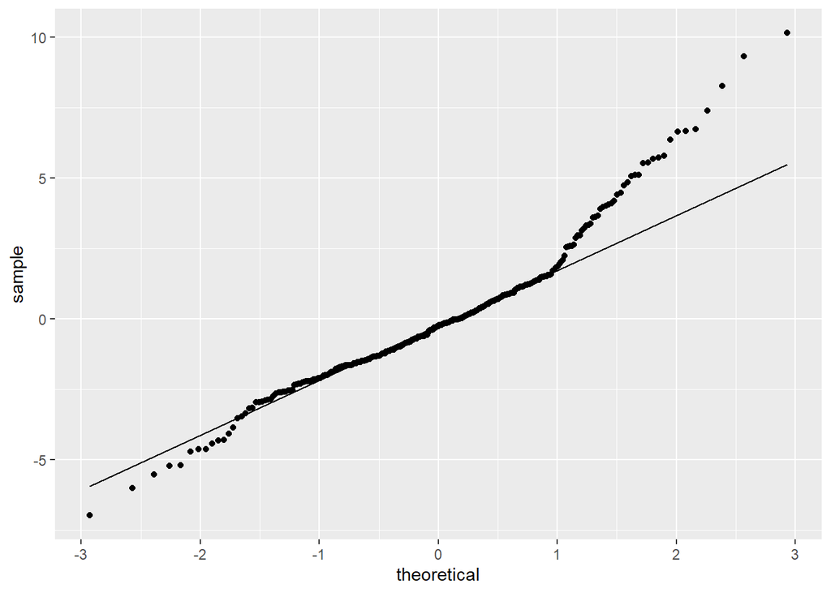

```r
ggplot(data = NULL, aes(sample = res)) +
  stat_qq() + stat_qq_line()
```

##Multicollinearity ##Investigate whether there is evidence of multicollinearity among our explanatory variables

```r
car::vif(fit)
```

```
##      TRB      AST       PF      BLK      STL
## 2.933312 1.990576 2.309960 2.137539 2.372578
```

##there can be seen some multicollinearity as the values are greater than 1

##Linearity ##Investigate the assumption of linearity.

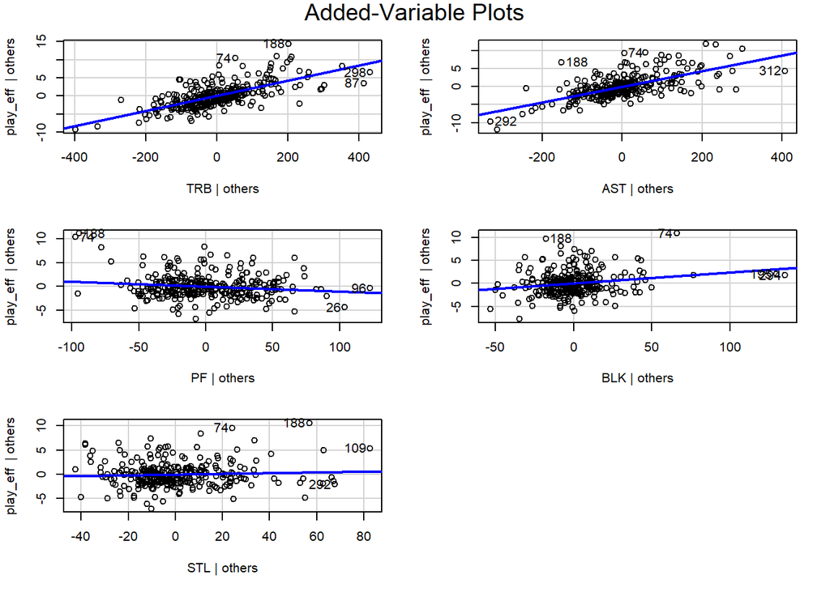

```r
car::avPlots(fit)
```

##Some points are tending to create non-linear patterns in the data, they seem to be similar to the points that may have been points of high influence. ## We could try transforming our data or investigate the use of a different model that is more robust to our data

##5. Player recommendations ##choosing player for position c

```r
fit2 <- new_df %>%
  filter(Pos == 'C' ) %>%
  lm(play_eff ~ TRB + AST + PF+ BLK + STL, data = .)
tidy(fit2, conf.int = TRUE)
```

```
## # A tibble: 6 x 7
##   term        estimate std.error statistic       p.value conf.low conf.high
##   <chr>          <dbl>     <dbl>     <dbl>         <dbl>    <dbl>     <dbl>
## 1 (Intercept)   4.05     1.24        3.25  0.00216         1.54     6.56
## 2 TRB           0.0224   0.00298     7.52  0.00000000176   0.0164   0.0284
## 3 AST           0.0230   0.00517     4.45  0.0000558       0.0126   0.0334
## 4 PF           -0.0232   0.0108     -2.16  0.0364         -0.0449  -0.00153
## 5 BLK           0.0370   0.0106      3.48  0.00112         0.0156   0.0584
## 6 STL          -0.0211   0.0219     -0.961 0.342          -0.0652   0.0231
```

```r
summary(fit2)
```

```
##
## Call:
## lm(formula = play_eff ~ TRB + AST + PF + BLK + STL, data = .)
##
## Residuals:
##     Min      1Q  Median      3Q     Max
## -3.5953 -1.7629 -0.1749  0.8401  9.1749
##
## Coefficients:
##              Estimate Std. Error t value Pr(>|t|)
## (Intercept)  4.049709   1.244522   3.254  0.00216 **
## TRB          0.022389   0.002979   7.517 1.76e-09 ***
## AST          0.022992   0.005166   4.451 5.58e-05 ***
## PF          -0.023215   0.010765  -2.157  0.03642 *
## BLK          0.036997   0.010626   3.482  0.00112 **
## STL         -0.021052   0.021911  -0.961  0.34179
## ---
## Signif. codes:  0 '***' 0.001 '**' 0.01 '*' 0.05 '.' 0.1 ' ' 1
##
## Residual standard error: 2.727 on 45 degrees of freedom
## Multiple R-squared:  0.8672, Adjusted R-squared:  0.8525
## F-statistic: 58.78 on 5 and 45 DF,  p-value: < 2.2e-16
```

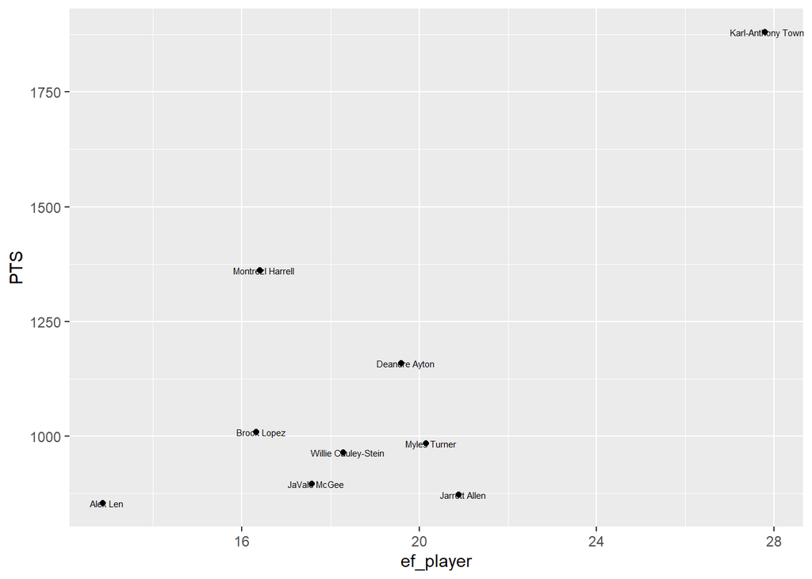

```r
new_df %>%
  filter(Pos == "C",BLK > mean(BLK),PTS > mean(PTS),
         TRB >mean(TRB),sal_mil< mean(sal_mil)) %>%
mutate(ef_player = predict(fit2, newdata = .)) %>%
  ggplot(aes(ef_player, PTS, label = player_name)) +
  geom_point() +
  geom_text(nudge_x=0.1, cex = 2) +
  geom_abline()
```

```r
c <- new_df %>% filter(Pos == "C",BLK > mean(BLK),PTS > mean(PTS),
                       TRB >mean(TRB),sal_mil< mean(sal_mil))  %>% top_n(10)
```

## player recommendations for this position is karl anthony towns where he has the highest efficiency and also available at 7.84 million

##choosing player for position pf

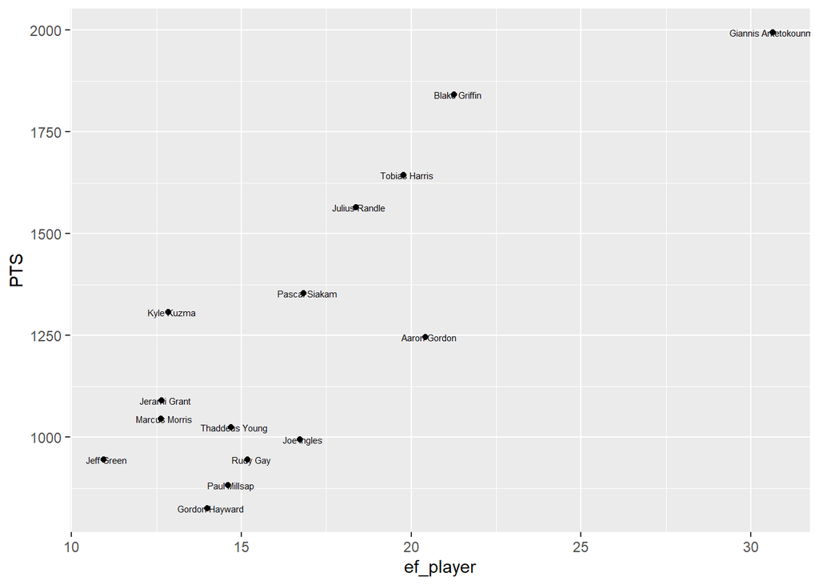

```r
new_df %>%
  filter(Pos == "PF",G > mean(G),PTS > mean(PTS), play_eff>mean(play_eff)) %>%
mutate(ef_player = predict(fit2, newdata = .)) %>%
  ggplot(aes(ef_player, PTS, label = player_name)) +
  geom_point() +
  geom_text(nudge_x=0.1, cex = 2) +
  geom_abline()
```

```r
pf <- new_df %>% filter(Pos == "PF",G > mean(G),PTS > mean(PTS), play_eff>mean(play_eff)) %>%top_n(10)
```

##choosing player for position pg

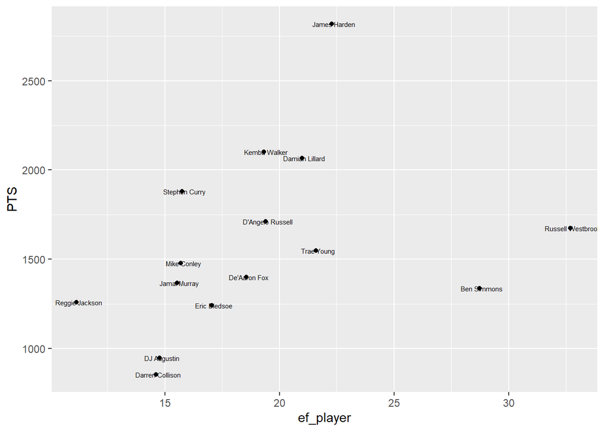

```r
new_df %>%
  filter(Pos == "PG",G > mean(G),PTS > mean(PTS), play_eff>mean(play_eff)) %>%
mutate(ef_player = predict(fit2, newdata = .)) %>%
  ggplot(aes(ef_player, PTS, label = player_name)) +
  geom_point() +
  geom_text(nudge_x=0.1, cex = 2) +
  geom_abline()
```

```r
pg <- new_df %>% filter(Pos == "PG",G > mean(G),PTS > mean(PTS), play_eff>mean(play_eff)) %>%top_n(10)
```

##choosing player for position sf

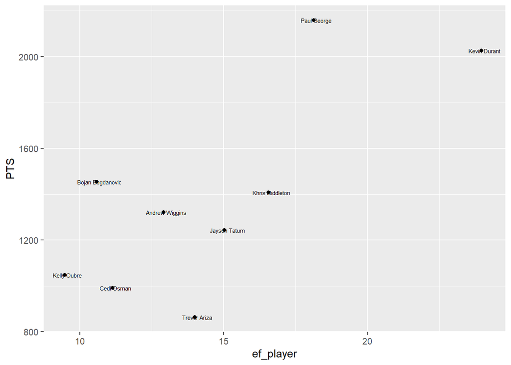

```r
new_df %>%
  filter(Pos == "SF",G > mean(G),PTS > mean(PTS), play_eff>mean(play_eff)) %>%
mutate(ef_player = predict(fit2, newdata = .)) %>%
  ggplot(aes(ef_player, PTS, label = player_name)) +
  geom_point() +
  geom_text(nudge_x=0.1, cex = 2) +
  geom_abline()
```

```r
pg <- new_df %>% filter(Pos == "SF",G > mean(G),PTS > mean(PTS), play_eff>mean(play_eff)) %>%top_n(10)
```

##player recommendations for this position is Kevin Durant where he has the highest efficiency and available at 30 million

##choosing player for position sg

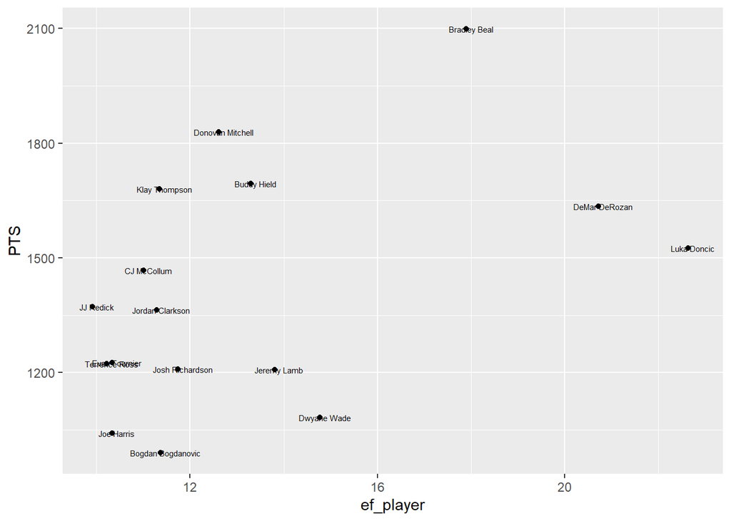

```r
new_df %>%
  filter(Pos == "SG",G > mean(G),PTS > mean(PTS), play_eff>mean(play_eff)) %>%
mutate(ef_player = predict(fit2, newdata = .)) %>%
  ggplot(aes(ef_player, PTS, label = player_name)) +
  geom_point() +
  geom_text(nudge_x=0.1, cex = 2) +
  geom_abline()
```

```r
pg <- new_df %>% filter(Pos == "SG",G > mean(G),PTS > mean(PTS), play_eff>mean(play_eff)) %>%top_n(10)
```

## 6. Summary

In gist we can conclude that most of the highly efficient players are highly expenisve and not all the costly players are chosen as there is a restraint not to use up all the money for the players itself. All differnt factors are considered and the analysis is done

## 7.references

1. Analyzing NBA Player Data I: Getting Data | R-bloggers [Internet]. R-bloggers. 2021 [cited 9 May 2021]. Available from: https://www.r-bloggers.com/2018/03/analyzing-nba-player-data-i-getting-data/
2. → H, → B, → C, (explained) B. Basketball Positions: Key Roles and Responsibilities (explained) [Internet]. Basketball For Coaches. 2021 [cited 9 May 2021]. Available from: https://www.basketballforcoaches.com/basketball-positions/
3. Irizarry R. Chapter 8 Visualizing data distributions | Introduction to Data Science [Internet]. Rafalab.github.io. 2021 [cited 9 May 2021]. Available from: https://rafalab.github.io/dsbook/distributions.html
4. Yesilyurt E. Determining the Players’ Efficiency in NBA: Some Economic and Managerial Results. International Journal of Sport Management, Recreation and Tourism. 2014;13:1-19.
5. Fein Z. Cracking the Code: How to Calculate Hollinger’s PER Without All the Mess [Internet]. Bleacher Report. 2021 [cited 9 May 2021]. Available from: https://bleacherreport.com/articles/113144-cracking-the-code-how-to-calculate-hollingers-per-without-all-the-mess
6. Basketball statistics - Wikipedia [Internet]. En.wikipedia.org. 2021 [cited 9 May 2021]. Available from: https://en.wikipedia.org/wiki/Basketball_statistics